# Cerebllar_organoid_brainspan_voxhunt

- genes used : HVG for organoids from integrated slot 2000 genes

```r
ref_map_2 <- brainspan_map(
    organoid,
    stages = 12:25,
    group_name = 'celltype',
    genes_use = organoid_high_var,
    pseudobulk_groups = T
)
print(ref_map_2)
```

```
## A BrainSpanMap object
## 12 cells mapped to
## 186 reference samples
## based on 1704 features
```

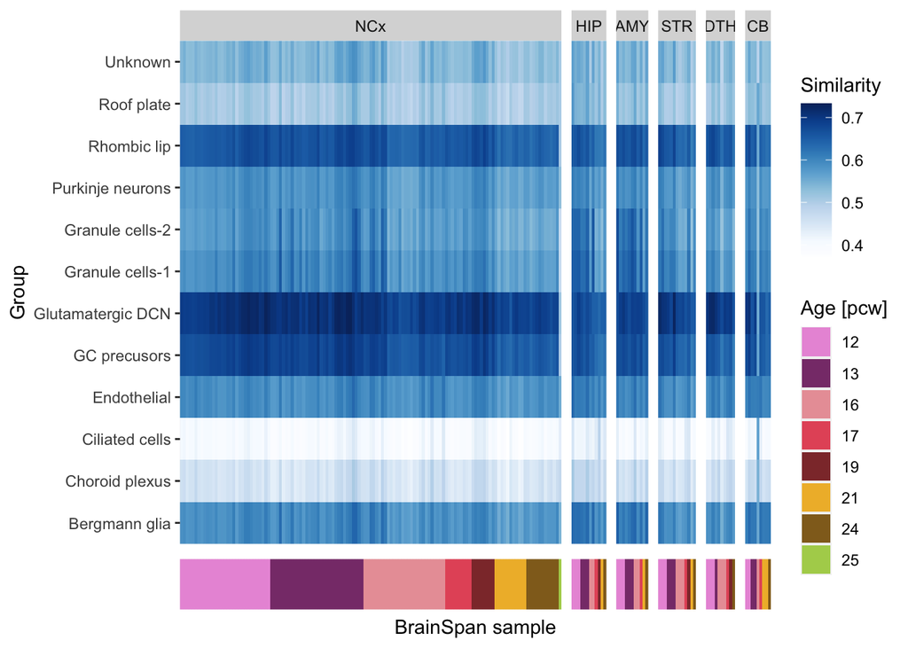

```r
plot_map(ref_map_2)
```

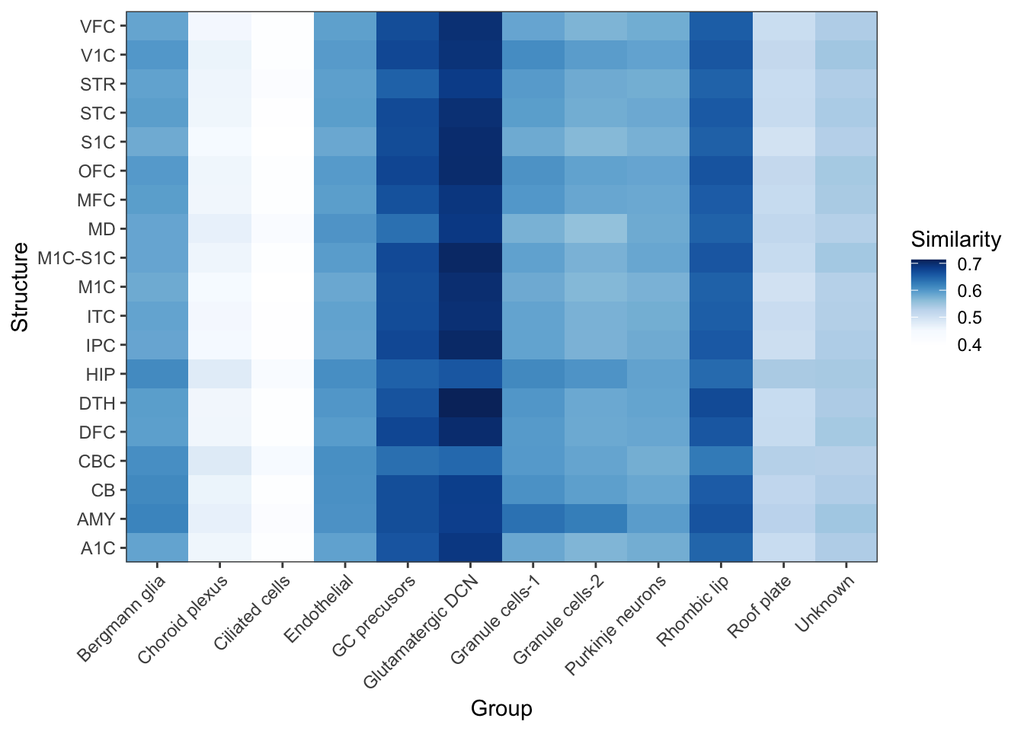

```r
plot_structure_similarity(ref_map_2, annotation_level = 'structure_name', scale = F)
```

```r
ref_map_3 <- brainspan_map(
    organoid,
    stages = 12:25,
    group_name = 'celltype',
    genes_use = brainspan_hvg,
    pseudobulk_groups = T
)
print(ref_map_3)
```

```
## A BrainSpanMap object
## 12 cells mapped to
## 186 reference samples
## based on 1069 features
```

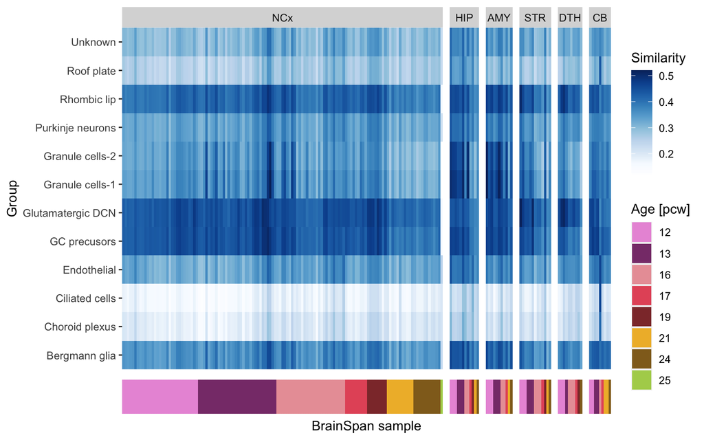

```r
plot_map(ref_map_3)
```

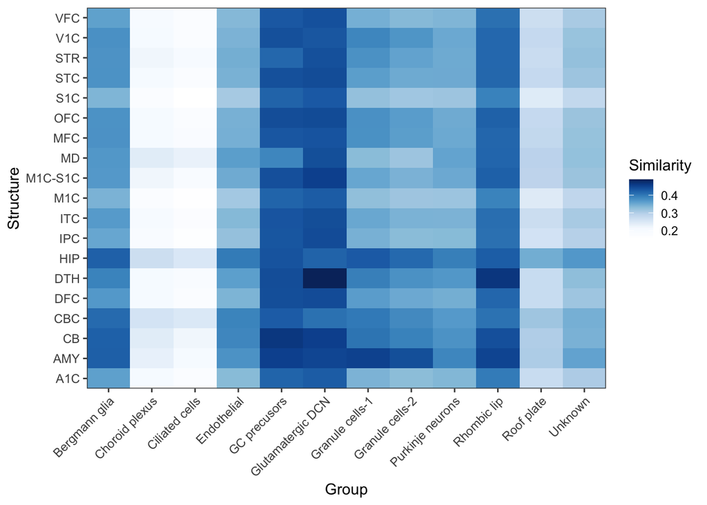

```r
plot_structure_similarity(ref_map_3, annotation_level = 'structure_name', scale = F)
```

- genes used : Intersection of Brainspan top 1000 HVG and Organoid 2000 integrated slot HVG genes

```r
intersected_hvg <- intersect(brainspan_hvg, organoid_high_var)
ref_map_4 <- brainspan_map(
    organoid,
    stages = 12:25,
    group_name = 'celltype',
    genes_use = intersected_hvg,
    pseudobulk_groups = T
)
print(ref_map_4)
```

```
## A BrainSpanMap object
## 12 cells mapped to
## 186 reference samples
## based on 471 features
```

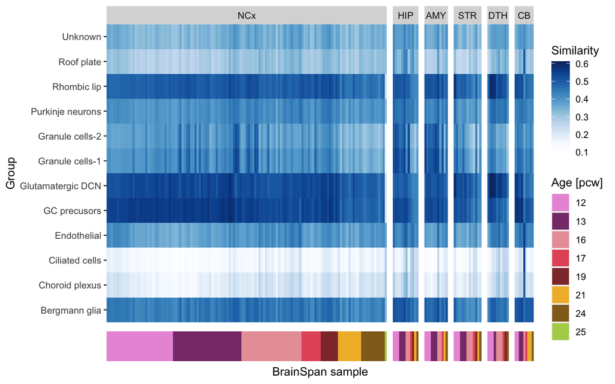

```r
plot_map(ref_map_4)
```

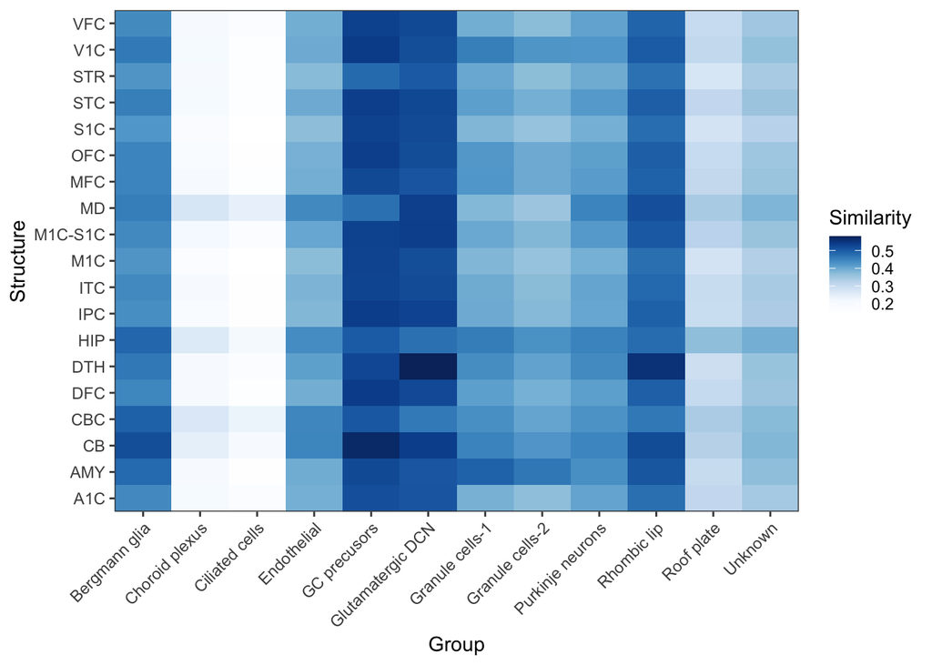

```r
plot_structure_similarity(ref_map_4, annotation_level = 'structure_name', scale = F)
```

- genes used : Brain span region after 10 PCW top 500 genes as opposed to region grouped based on pvalue < 0.05 and highest logFC

```r
intersected_hvg <- intersect(brainspan_hvg, organoid_high_var)
ref_map_5 <- brainspan_map(
    organoid,
    stages = 12:25,
    group_name = 'celltype',
    genes_use = genes_use_2,
    pseudobulk_groups = T
)
print(ref_map_5)
```

```
## A BrainSpanMap object
## 12 cells mapped to
## 186 reference samples
## based on 424 features
```

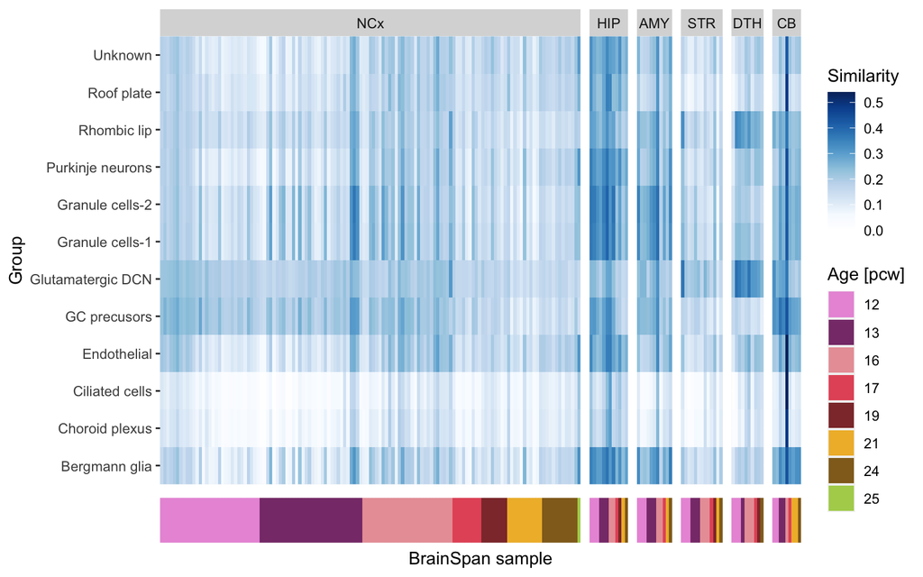

```r
plot_map(ref_map_5)
```

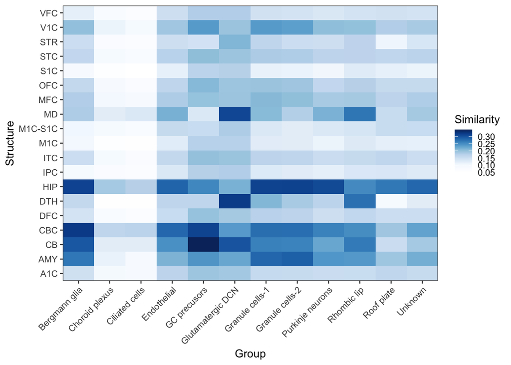

```r
plot_structure_similarity(ref_map_5, annotation_level = 'structure_name', scale = F)
```

In conclusion, we get the cleanest signal when I only use top 500 Brainspan region specific DEGs after pcw 10 based on FC. If use top 1000 the correlation becomes noisy.